# 贝叶斯第五章

模拟反事实的技巧在于，当我们操控某些变量X时，我们就打破了其他变量对X的因果影响。这就相当于我们修改DAG，使没有箭头进入X。假设我们现在模拟操控M的效果，这就意味着DAG:

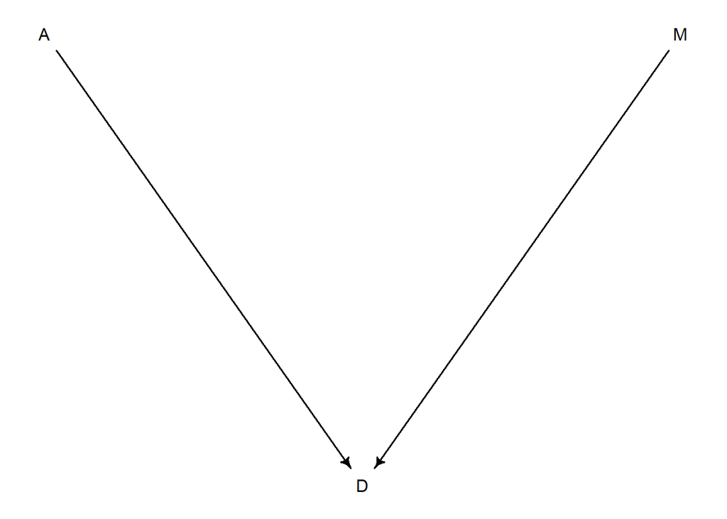

```r
dag5.3 <- dagitty( "dag{ A -> D;  M -> D }" )
coordinates(dag5.3) <- list( x=c(A=0,D=1,M=2) , y=c(A=0,D=1,M=0) )
drawdag( dag5.3 )
```

箭头A→M被删除，当A确定时，如果我们操控M的值，相当于A就不再能影响它。这就像一个完美控制的实验。现在我们可以修改上面的代码来模拟操纵M后的反事实结果。我们将模拟一个平均状态的反事实结果，当A = 0时，看看改变M会发生什么。

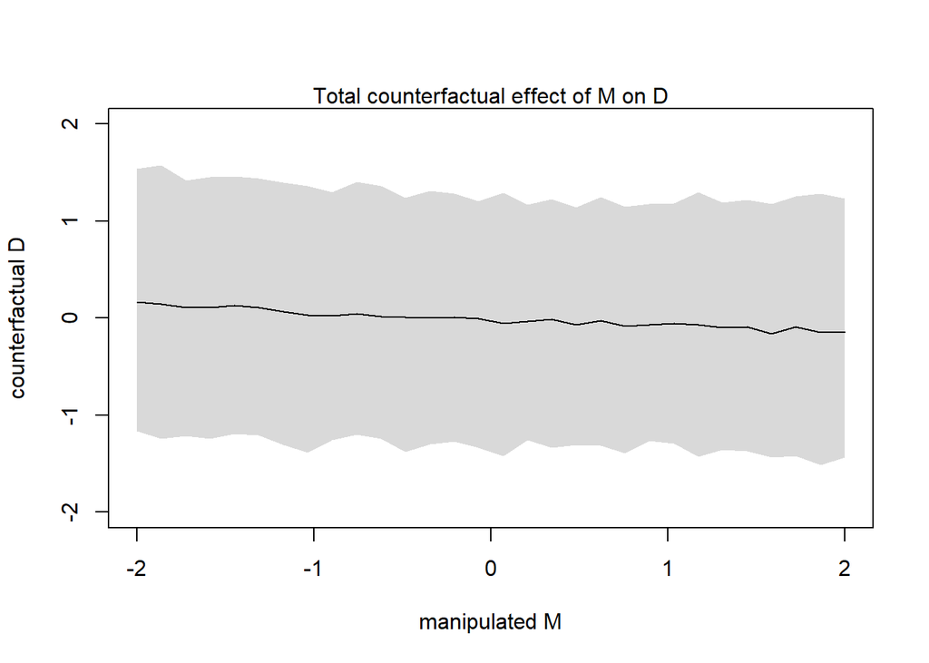

```r
sim_dat <- data.frame( M=seq(from=-2,to=2,length.out=30) , A=0 )
s <- sim( m5.3_A , data=sim_dat , vars="D" )
plot( sim_dat$M , colMeans(s) , ylim=c(-2,2) , type="l" ,
xlab="manipulated M" , ylab="counterfactual D" )
shade( apply(s,2,PI) , sim_dat$M )
mtext( "Total counterfactual effect of M on D" )
```

我们现在只模拟D——注意上面代码中sim()的vars参数只有D,因为A不影响M。如上图所示，这种趋势不那么强烈，因为没有证据表明M对D有很强的影响。

**拓展:模拟反事实。**本节中的示例使用sim()。但自己模拟反事实并不难。

假设我们已经拟合了模型m5.3_A，该模型包含了因果路径A→D和A→M→D。我们定义了一个想要分配给A的值范围:

```r
A_seq <- seq( from=-2 , to=2 , length.out=30 )
```

接下来我们需要提取后验估计，因为我们将模拟每组样本的观察结果。模型定义了M的分布，我们只需将该定义转换为相应的模拟函数，在本例中为rnorm:

```r
post <- extract.samples( m5.3_A )

# A -> M
M_sim <- with( post , sapply( 1:30 ,
function(i) rnorm( 1e3 , aM + bAM*A_seq[i] , sigma_M ) ) )
```

这里使用with函数，这样我们不必在每个参数名称前输入post$。rnorm中的线性模型直接来自于模型定义。这将生成一个值矩阵，对应于列中的A_seq中每一个值各生成1000个M。现在我们有了M的模拟值，我们也可以模拟D:

```r
# A→M→D←A 注意这里M用的是被A影响产生的M
D_sim <- with( post , sapply( 1:30 ,
function(i) rnorm( 1e3 , a + bA*A_seq[i] + bM*M_sim[,i] , sigma ) ) )
```

离婚率的例子表明，多元回归对于消除虚假关联是有用的。使用多个预测变量的第二个原因是当这些影响在单个预测变量和结果变量之间关系中都不明显时，衡量多个预测变量对结果的影响。当有两个相互关联的预测变量时，这类问题往往会出现，其中一个与结果变量正相关，另一个与结果变量负相关。

让我们从另一个数据集考虑这类问题，先将灵长类动物的母乳数据加载到R中:

```r
library(rethinking)
data(milk)
d <- milk
str(d)
```

```
## 'data.frame':    29 obs. of  8 variables:
##  $ clade         : Factor w/ 4 levels "Ape","New World Monkey",..: 4 4 4 4 4 2 2 2 2 2 ...
##  $ species       : Factor w/ 29 levels "A palliata","Alouatta seniculus",..: 11 8 9 10 16 2 1 6 28 27 ...
##  $ kcal.per.g    : num  0.49 0.51 0.46 0.48 0.6 0.47 0.56 0.89 0.91 0.92 ...
##  $ perc.fat      : num  16.6 19.3 14.1 14.9 27.3 ...
##  $ perc.protein  : num  15.4 16.9 16.9 13.2 19.5 ...
##  $ perc.lactose  : num  68 63.8 69 71.9 53.2 ...
##  $ mass          : num  1.95 2.09 2.51 1.62 2.19 5.25 5.37 2.51 0.71 0.68 ...
##  $ neocortex.perc: num  55.2 NA NA NA NA ...
```

在这个数据集中有29行观测8个变量。我们现在考虑的变量是kcal.per.g(每克母乳的千卡能量)，mass(平均雌性体重，单位:公斤)和neocortex.perc(大脑新皮层质量占大脑总质量的百分比)。

在这里探讨的问题是母乳的能量含量，在多大程度上与大脑中新皮层占大脑质量的比例有关。此外我们还需要用到雌性的体重，才能看到变量之间掩盖的关联。将这三个变量标准化，和前面的例子一样，标准化既可以帮助我们得到可靠的后验近似，又可以建立合理的先验分布。

```r
d$K <- standardize( d$kcal.per.g )
d$N <- standardize( d$neocortex.perc )
d$M <- standardize( log(d$mass) ) #注意这里用了自然对数处理
```

通常情况下，像体重这样的度量探究与其他变量的大小关系，会取一个度量的对数将度量转换（书上没提，个人猜测可能是为了克服异方差问题）。所以通过对数化处理后，我们怀疑母亲的体重大小与母乳的能量有线性的形式的关联。之后，在第十六章中，你会看到为什么这些对数关系几乎是生物物理学不可避免的结果。

第一个要考虑的模型是千卡和新皮层质量占比之间的简单一元回归。数学形式为:
$$K_i \sim \rm Normal(\mu_i,\sigma)$$
$$\mu_i = \alpha + \beta_N N_i$$

```r
d$neocortex.perc
```

```
##  [1] 55.16    NA    NA    NA    NA 64.54 64.54 67.64    NA 68.85 58.85 61.69
## [13] 60.32    NA    NA 69.97    NA 70.41    NA 73.40    NA 67.53    NA 71.26
## [25] 72.60    NA 70.24 76.30 75.49
```

注意，变量N中有缺失值，这很容易解决。在这里需要做的是手动删除所有缺少值的案例。这被称为完整的案例分析。直接删除含缺失值的观测不一定合适，有时会用到插值等其他处理方法，具体内容后面章节会提到。

这里采用complete.cases函数，生成一个新的数据集dcc，dcc每一行在complete.case中列出的任何变量中都没有缺失值。

```r
dcc <- d[ complete.cases(d$K,d$N,d$M) , ]
```

```r
 m5.5_draft <- quap(
  alist(
    K ~ dnorm( mu , sigma ) ,
    mu <- a + bN*N ,
    a ~ dnorm( 0 , 1 ) ,
    bN ~ dnorm( 0 , 1 ) ,
    sigma ~ dexp( 1 )
  ) , data=dcc )  #注意：这里先验分布的σ用了1
```

在许多简单的线性回归问题中，这些先验信息是无害的。但它们合理吗?建立合理的先验是很重要的，因为当模型变得不那么简单时，先验会非常有用，但前提是它们在科学上是合理的。模拟并绘制50条先验的回归线:

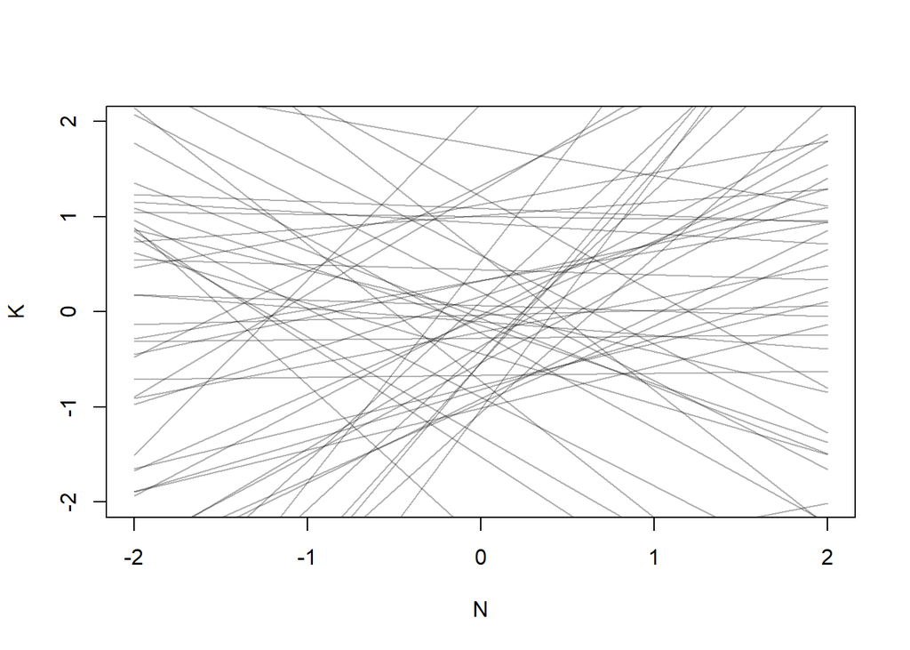

```r
prior <- extract.prior( m5.5_draft )
xseq <- c(-2,2)
mu <- link( m5.5_draft , post=prior , data=list(N=xseq) )
plot( NULL , xlim=xseq , ylim=xseq , xlab = "N" , ylab = "K")
for ( i in 1:50 ) lines( xseq , mu[i,] , col=col.alpha("black",0.3) )
```

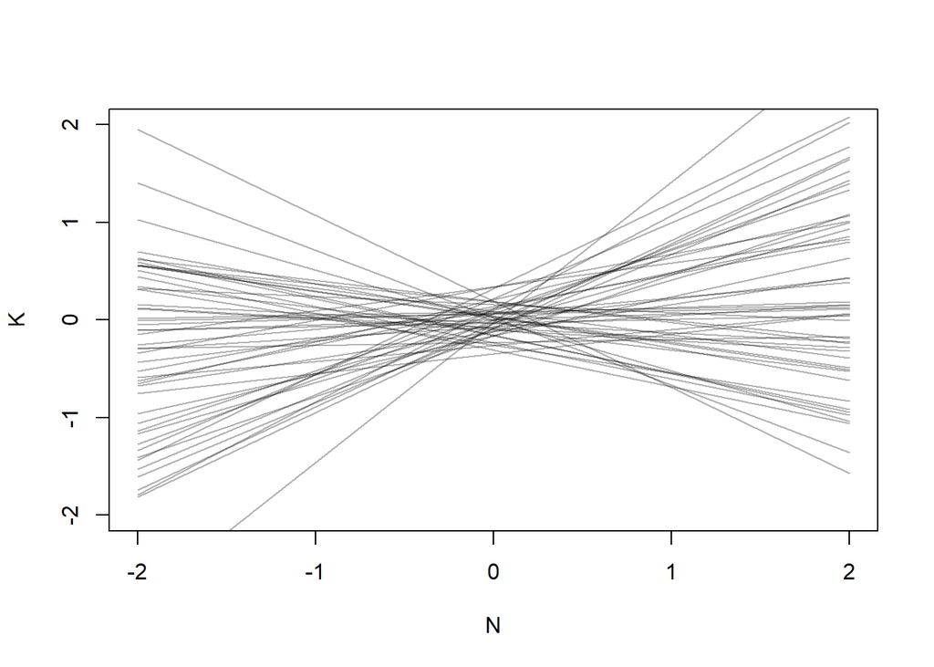

```r
m5.5 <- quap(
alist(
K ~ dnorm( mu , sigma ) ,
mu <- a + bN*N ,
a ~ dnorm( 0 , 0.2 ) ,
bN ~ dnorm( 0 , 0.5 ) ,
sigma ~ dexp( 1 )
) , data=dcc )

prior <- extract.prior( m5.5 )
xseq <- c(-2,2)
mu <- link( m5.5 , post=prior , data=list(N=xseq) )
plot( NULL , xlim=xseq , ylim=xseq , xlab = "N" , ylab = "K")
for ( i in 1:50 ) lines( xseq , mu[i,] , col=col.alpha("black",0.3) )
```

这仍然是非常模糊的先验信息,但感觉比之前好很多。接着看后验分布情况：

```r
precis(m5.5)
```

```
##             mean        sd       5.5%     94.5%
## a     0.03993934 0.1544908 -0.2069667 0.2868454
## bN    0.13323586 0.2237468 -0.2243548 0.4908265
## sigma 0.99982012 0.1647080  0.7365850 1.2630553
```

从这个摘要中可以发现，N与K之间既不是很强也不是非常精确的关系。我们可以绘制预测平均值和平均值的89%兼容区间，以便更容易看到这一点。下面的代码在xseq中扩展N值的范围，使图看起来会更好。

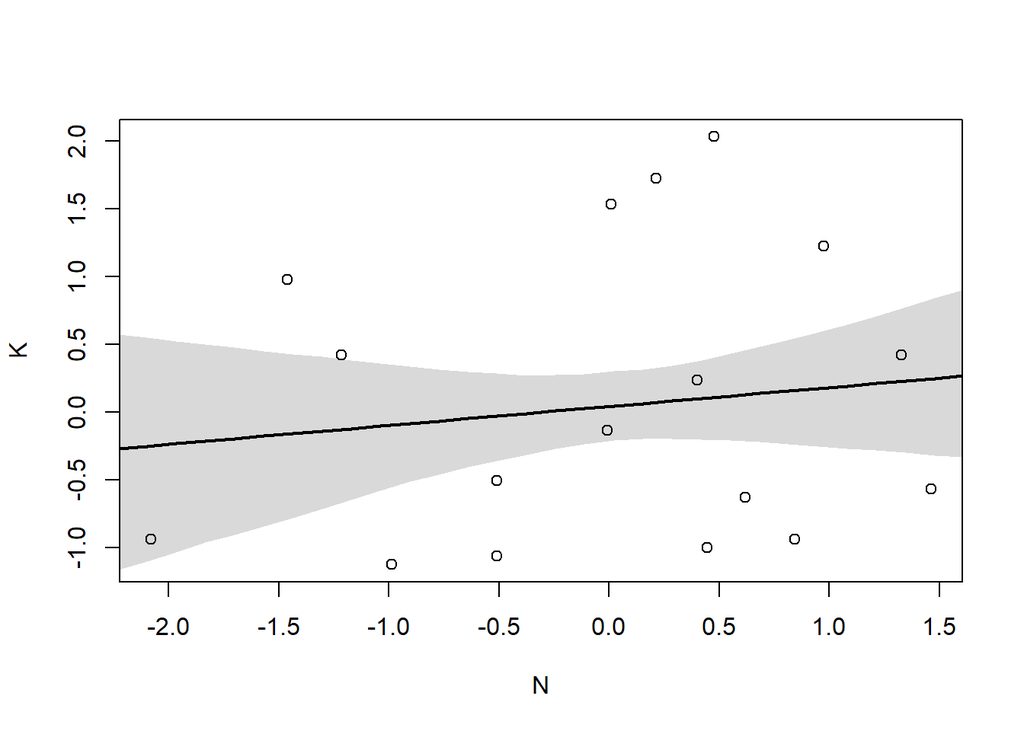

```r
xseq <- seq( from=min(dcc$N)-0.15 , to=max(dcc$N)+0.15 , length.out=30 ) #向左右扩0.15
mu <- link( m5.5 , data=list(N=xseq) )
mu_mean <- apply(mu,2,mean)
mu_PI <- apply(mu,2,PI)
plot( K ~ N , data=dcc )
lines( xseq , mu_mean , lwd=2 )
shade( mu_PI , xseq )
```

如图所示，后验均值线表现为很弱的正相关关系，精度很低。

现在我们考虑另一个预测变量，成年雌性的体重，即数据框中的mass。我们用mass的对数，log(mass)作为预测变量。构建了一个考虑千卡能量和体重之间的关系的模型。体重也是标准化处理的，同时可以使用相同的先验信息。

```r
m5.6 <- quap(
  alist(
    K ~ dnorm( mu , sigma ) ,
    mu <- a + bM*M ,
    a ~ dnorm( 0 , 0.2 ) ,
    bM ~ dnorm( 0 , 0.5 ) ,
    sigma ~ dexp( 1 )
  ) , data=dcc )
precis(m5.6)
```

```
##              mean        sd       5.5%      94.5%
## a      0.04654152 0.1512800 -0.1952332 0.28831622
## bM    -0.28253540 0.1928818 -0.5907977 0.02572694
## sigma  0.94927929 0.1570615  0.6982647 1.20029386
```

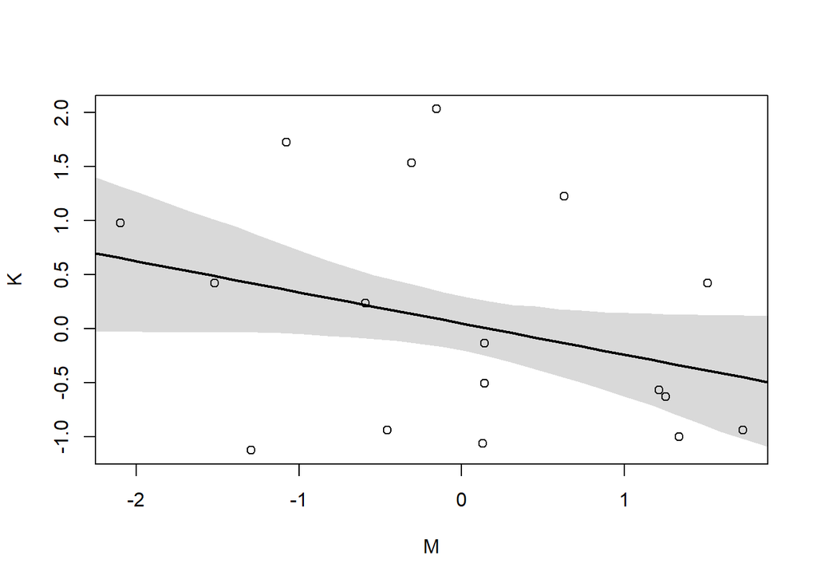

```r
xseq <- seq( from=min(dcc$M)-0.15 , to=max(dcc$M)+0.15 , length.out=30 )
mu <- link( m5.6 , data=list(M=xseq) )
mu_mean <- apply(mu,2,mean)
mu_PI <- apply(mu,2,PI)
plot( K ~ M , data=dcc )
lines( xseq , mu_mean , lwd=2 )
shade( mu_PI , xseq )
```

logmass与千卡能量呈负相关。这种关联似乎比新皮层质量占比的关联更强，但方向相反。这是关联也是相当不确定的，它也有一个很宽的兼容区间。

现在让我们看看，当我们同时将两个预测变量加入回归时，会发生什么。这是多元模型的数学形式:
$$K_i \sim \rm Normal(\mu_i,\sigma)$$
$$\mu_i = \alpha + \beta_N N_i + \beta_M
M_i$$
$$\alpha \sim \rm
Normal(0,0.2)$$
$$\beta_N \sim \rm
Normal(0,0.5)$$
$$\beta_M \sim \rm
Normal(0,0.5)$$
$$\sigma \sim \rm
Exponential(1)$$

```r
m5.7 <- quap(
  alist(
    K ~ dnorm( mu , sigma ) ,
    mu <- a + bN*N + bM*M ,
    a ~ dnorm( 0 , 0.2 ) ,
    bN ~ dnorm( 0 , 0.5 ) ,
    bM ~ dnorm( 0 , 0.5 ) ,
    sigma ~ dexp( 1 )
  ) , data=dcc )
precis(m5.7)
```

```
##              mean        sd       5.5%      94.5%
## a      0.06799175 0.1339987 -0.1461640  0.2821475
## bN     0.67511799 0.2482985  0.2782890  1.0719470
## bM    -0.70299083 0.2207870 -1.0558510 -0.3501306
## sigma  0.73801398 0.1324617  0.5263146  0.9497133
```

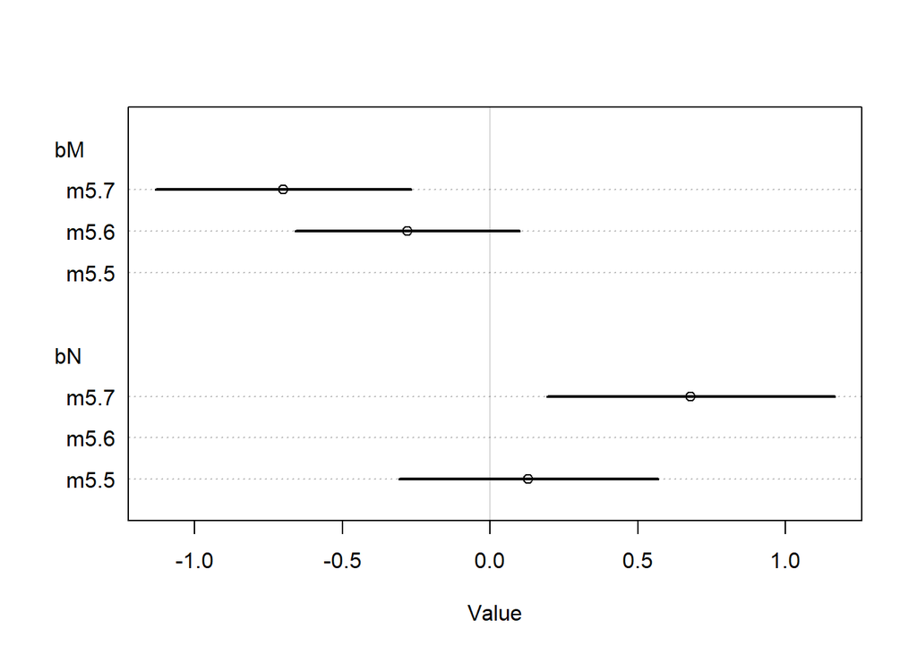

```r
plot( coeftab( m5.5 , m5.6 , m5.7 ) , pars=c("bM","bN") )
```

从摘要和图形中发现，通过在回归中加入两个预测变量，两者与结果变量的后验关系增强了。

这里发生了什么?为什么在同一个模型中加入新皮层质量占比和体重会导致两者之间更强的联系?在这种情况下，有两个变量与结果变量相关，但一个与结果正相关，另一个与结果负相关。此外，两个解释变量之间都呈正相关关系。尝试一个简单的pairs(~K + M + N, dcc)图来直观感受这种相关形式。这种形式的结果是，变量往往会相互抵消。

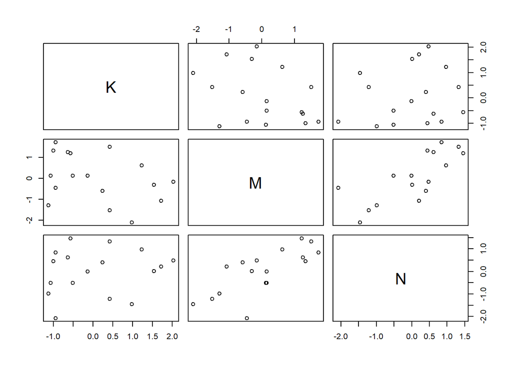

```r
pairs(~K + M + N, dcc)
```

这是除5.1外的另一种混淆的情况。回归模型所做的是“询问”那些新皮层质量占比高的物种是否有更高的乳汁能量。同样地，该模型还会“问”身体质量高的物种是否有更高的乳汁能量。事实上，质量较大的物种，乳汁的能量较少，类人猿质量就比较大，但是像类人猿这种拥有更高新皮层质量占比的物种往往拥有更丰富的乳汁。做一元回归的时候，回归模型就感觉困惑了。身体大小和新皮层占比这两个变量在物种间是相互关联的，除非我们把两者都考虑进去，否则我们很难看到这些关系。

还可以画一些反事实图

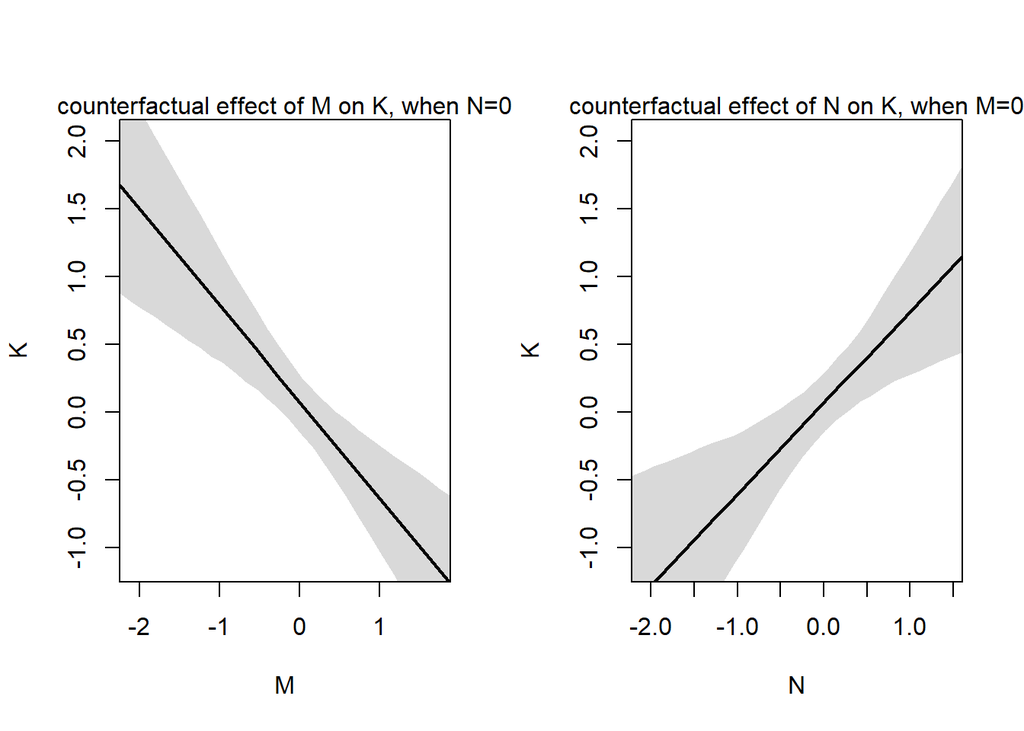

```r
par(mfrow=c(1,2))

#控制N=0时M和K关系的反事实图
xseq <- seq( from=min(dcc$M)-0.15 , to=max(dcc$M)+0.15 , length.out=30 )
mu <- link( m5.7 , data=data.frame( M=xseq , N=0 ) )
mu_mean <- apply(mu,2,mean)
mu_PI <- apply(mu,2,PI)
plot( NULL , xlim=range(dcc$M) , ylim=range(dcc$K) , xlab = "M" , ylab = "K")
lines( xseq , mu_mean , lwd=2 )
shade( mu_PI , xseq )
mtext( "counterfactual effect of M on K, when N=0" )

#控制M=0时N和K关系的反事实图
xseq <- seq( from=min(dcc$N)-0.15 , to=max(dcc$N)+0.15 , length.out=30 )
mu <- link( m5.7 , data=data.frame( N=xseq , M=0 ) )
mu_mean <- apply(mu,2,mean)
mu_PI <- apply(mu,2,PI)
plot( NULL , xlim=range(dcc$N) , ylim=range(dcc$K) , xlab = "N" , ylab = "K")
lines( xseq , mu_mean , lwd=2 )
shade( mu_PI , xseq )
mtext( "counterfactual effect of N on K, when M=0" )
```

这个数据可能有三个DAG能表示因果关系：

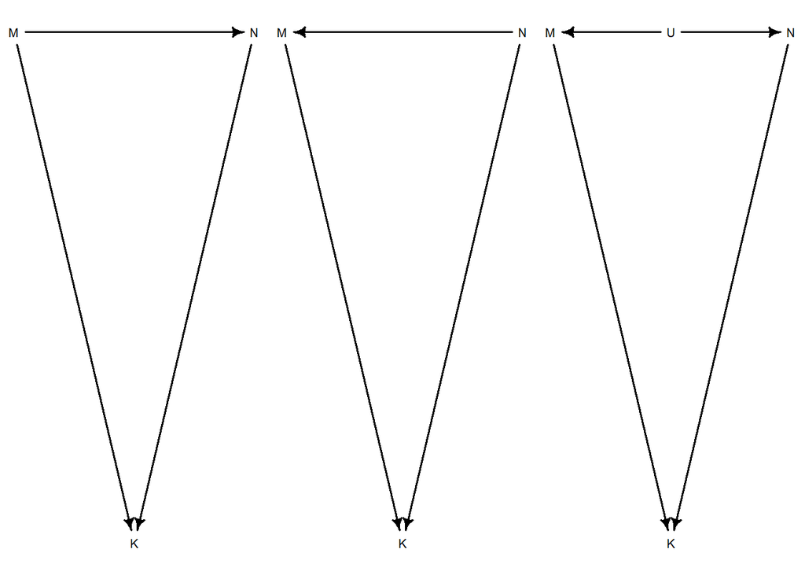

```r
par(mfrow=c(1,3))

dag5.4 <- dagitty( "dag{ M -> N;  M -> K; N -> K}" )
coordinates(dag5.4) <- list( x=c(M=0,K=1,N=2) , y=c(M=0,K=1,N=0) )
drawdag( dag5.4 )

dag5.5 <- dagitty( "dag{ N -> M;  M -> K; N -> K}" )
coordinates(dag5.5) <- list( x=c(M=0,K=1,N=2) , y=c(M=0,K=1,N=0) )
drawdag( dag5.5 )

dag5.6 <- dagitty( "dag{ U -> M; U -> N; M -> K; N -> K}" )
coordinates(dag5.6) <- list( x=c(M=0,K=1,N=2,U=1) , y=c(M=0,K=1,N=0,U=0) )
drawdag( dag5.6 )
```

第一种是说可能是体重(M)影响新皮层质量占比(N)。然后两者都影响乳汁中的热量(K)。第二种，新皮层质量占比反过来影响体重。最后一种，可能有一个未观察到的变量U影响M和N，使它们之间产生相关性。对因果推断的威胁之一是，有许多潜在的未观察到的变量会影响结果或预测因素。我们将在下一章进一步讨论这个问题。

哪个DAG是正确的?我们不能仅从数据中判断，因为这些图表暗示了相同的条件独立性。在这种情况下，不管我们的条件是什么，上面的每个DAG都暗示所有变量对都是相关的。**一组具有相同条件独立性的DAG称为马尔可夫等价集。**在下面的拓展中，将展示如何模拟与这些DAG一致的观察结果，它们如何产生掩盖现象，以及如何使用dagitty包计算完整的马尔科夫等价集。虽然数据本身永远不能告诉我们哪个因果模型是正确的，但通过数据可以排除大量不可能的马尔可夫等价集。

**拓展:模拟掩盖关系。**

要模拟与三个DAG一致的数据:

```r
# M -> K <- N
# M -> N
n <- 100
M <- rnorm( n )
N <- rnorm( n , M )
K <- rnorm( n , N - M )
d_sim <- data.frame(K=K,N=N,M=M)

# M -> K <- N
# N -> M
n <- 100
N <- rnorm( n )
M <- rnorm( n , N )
K <- rnorm( n , N - M )
d_sim2 <- data.frame(K=K,N=N,M=M)

# M -> K <- N
# M <- U -> N
n <- 100
U <- rnorm( n )
N <- rnorm( n , U )
M <- rnorm( n , U )
K <- rnorm( n , N - M )
d_sim3 <- data.frame(K=K,N=N,M=M)
```

以下代码用equivalentDAGs函数可以求某一个DAG的所有马尔科夫等价集

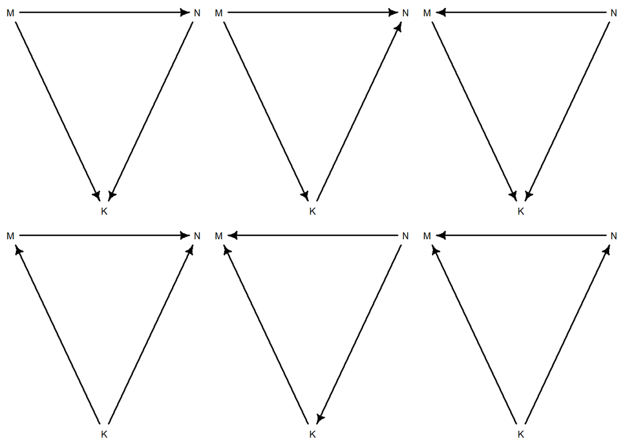

```r
dag5.7 <- dagitty( "dag{
M -> K <- N
M -> N }" )
coordinates(dag5.7) <- list( x=c(M=0,K=1,N=2) , y=c(M=0.5,K=1,N=0.5) )
MElist <- equivalentDAGs(dag5.7)
drawdag( MElist )
```

5.3分类变量

分类变量是同时具有离散性和无序性的变量，离散性表明取值不可能介于两个类别之间，无序性类别之间没有大小可以比较。

##5.3.1. 二分变量。

在最简单的情况下，感兴趣的变量只有两个类别，如男性和女性。第四章我们在预测身高时忽略了性别，但显然我们认为男性和女性的平均身高不同。看看可用的变量:

```r
library(rethinking)
data(Howell1)
d <- Howell1
str(d)
```

```
## 'data.frame':    544 obs. of  4 variables:
##  $ height: num  152 140 137 157 145 ...
##  $ weight: num  47.8 36.5 31.9 53 41.3 ...
##  $ age   : num  63 63 65 41 51 35 32 27 19 54 ...
##  $ male  : int  1 0 0 1 0 1 0 1 0 1 ...
```

male变量是指标变量的一个例子。指示变量——有时也称为哑变量——是将无序类别编码到定量模型中的工具。当这个人是男性时，它的值为1，但当这个人属于任何其他类别时，它的值为0。值为0的那个类别称为参考类别。

有两种方法可以处理分类变量。第一种方法就是使用指示变量。再次考虑第四章所述的身高的线性模型。现在我们将忽略体重和其他变量，只关注性别。
$$h_i \sim \rm Normal(\mu_i,\sigma)$$
$$\mu_i = \alpha + \beta_m m_i$$
$$\alpha \sim \rm Normal(178,20)$$
$$\beta_m \sim \rm Normal(0,10)$$
$$\sigma \sim \rm Uniform(0,50)$$
用哑变量编码这种方法，意味着βm代表男性和女性的期望身高差。参数α被用来预测女性和男性的身高。但是男性的身高会多出一个βm。这也意味着α不再是样本中的平均身高，而只是女性的平均身高。这使得分配合理的先验分布变得有点困难。如果对预期的身高差异没有概念——在看到数据之前，什么才是合理的呢?这种方法可能会很麻烦。当然在这种情况下，因为数据较多，可以使用模糊的先验。

哑变量编码的另一个问题是，这种方法必然假设其中一个类别(在这个例子中是“男性”)比另一个类别有更多的不确定性。为什么呢?因为对男性的预测包括两个参数和两个先验分布：

```r
mu_female <- rnorm(1e4,178,20)
mu_male <- rnorm(1e4,178,20) + rnorm(1e4,0,10)
precis( data.frame( mu_female , mu_male ) )
```

```
##               mean       sd     5.5%    94.5%  histogram
## mu_female 178.1634 19.99867 146.0527 210.3204 ▁▁▁▃▇▇▂▁▁▁
## mu_male   178.2408 22.15103 143.1923 213.7875  ▁▁▁▃▇▇▃▁▁
```

处理分类变量的另一种方法是索引变量（index variable）索引变量包含与不同类别对应的整数。这些整数只是名称，它们允许我们引用相应的参数列表，每个类别对应一个参数。在这种情况下，一个分类变量的参数会形成一个向量，当样本为第i类时，参数向量第i个位置的参数被“打开”，其余的参数“关闭”，事实上就是我们常说的热独编码。我们可以像这样构建索引:

```r
d$sex <- ifelse( d$male==1 , 2 , 1 )
str( d$sex )
```

```
##  num [1:544] 2 1 1 2 1 2 1 2 1 2 ...
```

此时模型用数学公式表达为：
$$h_i \sim \rm
Normal(\mu_i,\sigma)$$
$$\mu_i =
\alpha_{SEX[i]}$$
$$\alpha_j \sim \rm
Normal(178,20) \quad for \quad j = 1..2$$
$$\sigma \sim \rm Uniform(0,50)$$
在这个例子中，我们得到两个α参数，分别是α1和α2。这两种类型都没有比另一种更多的先验不确定性。

对上面使用索引变量的模型进行后验近似。

```r
m5.8 <- quap(
alist(
height ~ dnorm( mu , sigma ) ,
mu <- a[sex] ,
a[sex] ~ dnorm( 178 , 20 ) ,
sigma ~ dunif( 0 , 50 )
) , data=d )
precis( m5.8 , depth=2 )
```

```
##            mean        sd      5.5%     94.5%
## a[1]  134.91167 1.6069843 132.34339 137.47994
## a[2]  142.56814 1.6975203 139.85517 145.28111
## sigma  27.31082 0.8281065  25.98734  28.63429
```

它们展示了不同性别的身高的期望。我们常常关心的是性别差异，怎么做？可以用后验样本计算。

```r
 post <- extract.samples(m5.8)
post$diff_fm <- post$a[,1] - post$a[,2]
precis( post , depth=2 )
```

```
##               mean        sd      5.5%      94.5%      histogram
## sigma    27.309741 0.8206765  26.00828  28.622586  ▁▁▁▁▃▅▇▇▃▂▁▁▁
## a[1]    134.870234 1.6022523 132.31637 137.442620  ▁▁▁▁▂▅▇▇▅▂▁▁▁
## a[2]    142.555988 1.6993281 139.83788 145.280992 ▁▁▁▁▂▃▇▇▇▃▂▁▁▁
## diff_fm  -7.685753 2.3215698 -11.35893  -4.023397     ▁▁▁▂▇▇▃▁▁▁
```

diff_fm作为一个后验的新参数。这是样本中女性和男性之间的预期差异。

##5.3.2 多分类变量

无论使用指示变量还是索引变量，二分变量的分类很容易。但是当有两个以上的类别时，你需要为每个新的类别设置一个新的指示变量。如果有k个不同的类别，则需要k−1个指示变量。像R的lm这样的自动化工具实际上走的是这条路，为你构造k−1的指示变量，并返回k−1个回归系数。

这里我们坚持使用索引变量方法。在二分类基础上添加更多的类别时，它的形式不会改变，同样先验信息的表示也更容易。

```r
data(milk)
d <- milk
levels(d$clade)
```

```
## [1] "Ape"              "New World Monkey" "Old World Monkey" "Strepsirrhine"
```

```r
d$clade_id <- as.integer( d$clade )
```

此时用公式把模型表示为：
$$K_i \sim \rm
Normal(\mu_i,\sigma)$$
$$\mu_i = \rm
\alpha_{CLADE[i]}$$
$$\alpha_j \sim
\rm Normal(0,0.5) \quad for \quad j = 1..4$$
$$\sigma \sim \rm Exponential(1)$$
K进行了标准化。我们把α上的先验扩大了一点，允许不同的clade分散。

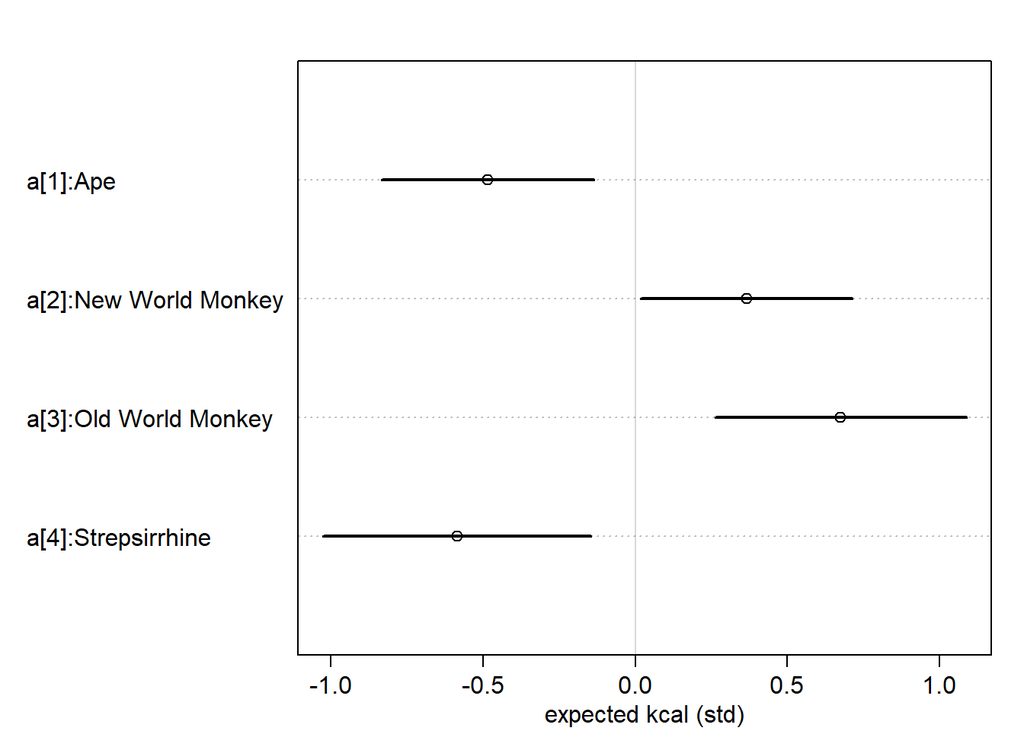

```r
d$K <- standardize( d$kcal.per.g )
  m5.9 <- quap(
    alist(
    K ~ dnorm( mu , sigma ),
    mu <- a[clade_id],
    a[clade_id] ~ dnorm( 0 , 0.5 ),
    sigma ~ dexp( 1 )
  ) , data=d )


labels <- paste( "a[" , 1:4 , "]:" , levels(d$clade) , sep="" )
plot( precis( m5.9 , depth=2 , pars="a" ) , labels=labels ,
xlab="expected kcal (std)" )
```

如果你有另一种类别变量，你想添加到模型中，方法是一样的。例如，让我们将这些灵长类动物随机分配到一些虚构的类别中:[1]Gryffindor，[2]Hufflepuff，[3]Ravenclaw，[4]Slytherin。

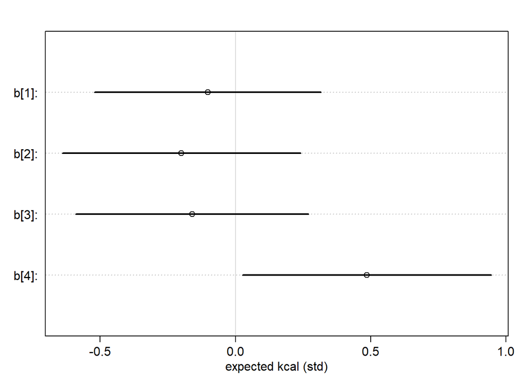

```r
set.seed(63)
d$house <- sample( rep(1:4,each=8) , size=nrow(d) )

m5.10 <- quap(
  alist(
    K ~ dnorm( mu , sigma ),
    mu <- a[clade_id] + h[house],
    a[clade_id] ~ dnorm( 0 , 0.5 ),
    h[house] ~ dnorm( 0 , 0.5 ),
    sigma ~ dexp( 1 )
  ) , data=d )


labels <- paste( "b[" , 1:4 , "]:" , levels(d$house) , sep="" )
plot( precis( m5.10 , depth=2 , pars="h" ) , labels=labels ,
xlab="expected kcal (std)" )
```

**反思:差异和统计显著性。** 在解释参数估计结果时，一个常见的误区是，一个参数离零足够远——即“显著”，而另一个参数“不显著”时，参数之间的差异也显著。事实未必如此，如果你想知道一个差值的分布，那么你必须计算这个差值。

例如，男性的斜率与零有很多重叠，而女性的斜率则可靠地高于零。你必须计算男性和女性之间斜率差的后验分布。例如，假设有两个参数βf和βm的后验分布。βf的均值和标准差为0.15±0.02，βm的均值和标准差为0.02±0.10。因此，虽然βf显著地不同于零，而βm则不是，但两者之间的差值(假设它们不相关)为$(0.15−0.02)±\sqrt{0.02^2 + 0.1^2}≈0.13±0.10$。差值的分布与零有很多重叠。换句话说，你可以确信βf远离零，但你不能确定βf和βm之间的差远离零。

在非贝叶斯显著性检验的背景下，这一现象源于这样一个事实:统计显著性在某种程度上具有推理能力:即与零值的差异。当参数与包含0时，它也可能包含远离零的值，它的值是不确定的。因此，当你比较βm和βf时，这种比较也是不确定的，在贝叶斯统计中表现为βf - βm的后验分布的宽度。

这个例子背后隐藏着一个解释统计显著性的更基本错误:接受零假设的错误。每当一篇文章或一本书说“我们发现没有区别”或“没有影响”，这通常意味着某些参数与零没有显著不同，因此作者采用零作为估计。这既不合逻辑又极其普遍。

本章介绍了多元回归，这是一种构建描述性模型的方法，用来描述测量的平均值与多个预测变量是如何关联的。多元回归的定义问题是:一旦我们已经知道了其他的预测因素，知道每个预测因素的价值是什么?这个问题的答案本身并没有提供任何因果信息。因果推断需要额外的假设。因果关系的有向无环图(DAG)模型是表示这些假设的一种方法。在下一章中，我们将继续构建DAG框架，并了解添加预测变量如何产生和解决尽可能多的问题。